# PA1_template

Guillem Mitjà

9/1/2021

# Read the activity data

By this code, the file activity.csv is read and the dates converted to the proper date type

```r
Activity <- read.csv("activity.csv")
Activity$date <- as.Date(as.character(Activity$date),"%Y-%m-%d")
```

# Calculation of the total number of steps per day

Now, the total number of steps per day is calculated and plot in the following histogram

[figure not shown]

# Mean and median of steps per day

The calculated mean of the steps per day is 10766.19 steps. The median is 10765 steps.

# Calculate Daily pattern

The following plot shows an averaged daily pattern for each interval of five minuts accross a day.

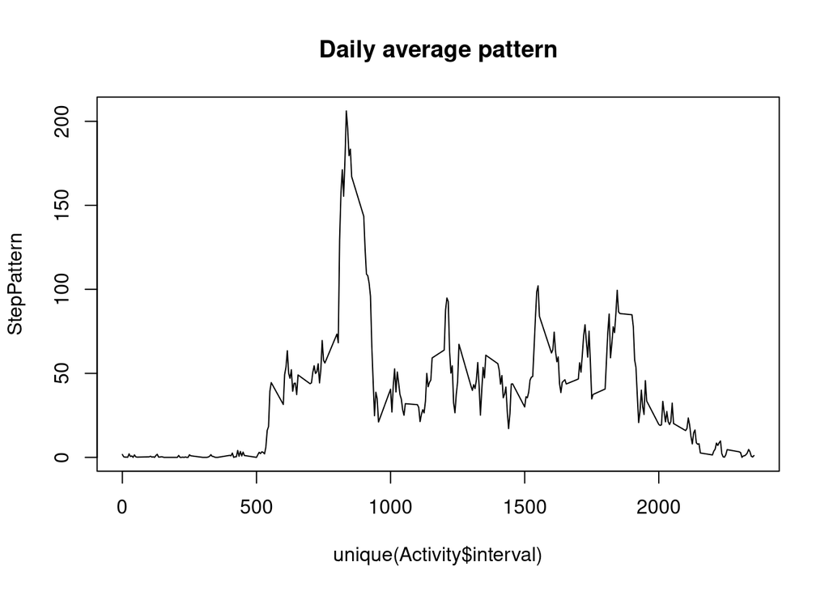

# Missing values adjustment and analysis

The total number of missing values is 2304. We can see how they compare to the values that are no na.

| Var1 | Freq |
| --- | --- |
| Good values | 15264 |
| NA values | 2304 |

# Filling the gaps

Using this code, the values that are NA are filled with the mean value for that specific interval for all the recorded measurements.

```r
ActivityNoNa <- Activity
for (i in 1:length(Activity$steps)) {
  if (is.na(Activity$steps[i])){
    if (i%%288 == 0){
      ActivityNoNa$steps[i] <- StepPattern[[288]]
    }else{
      ActivityNoNa$steps[i] <- StepPattern[[i %% 288]]}
    } else{
      ActivityNoNa$steps[i] <- Activity$steps[i]
    }
}
```

## Calculate mean and median

Once we have filled the NA gaps, the histogram of the total steps per day is generated again to compare the values after the NA removal.

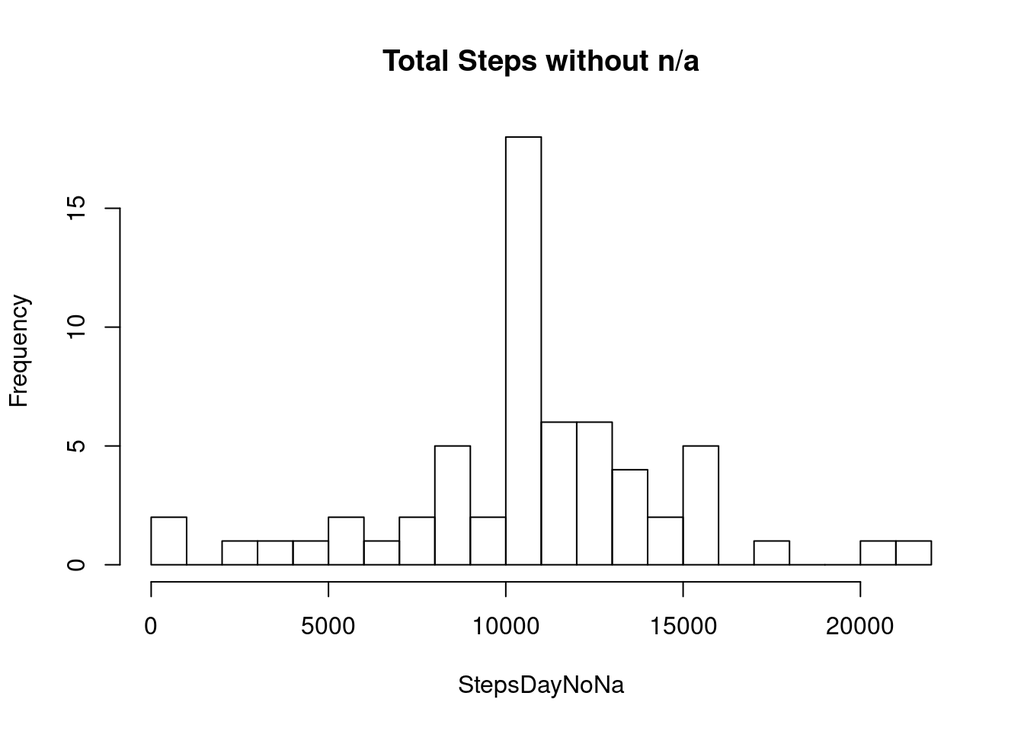

The calculated mean of the steps per day after NA removal is 10766.19 steps. The median is 10766.19 steps. The following table shows the comparison

|  | Original | NA removed |
| --- | --- | --- |
| mean | 10766.19 | 10766.19 |
| median | 10765.00 | 10766.19 |

# Weekdays and weekend comparison

The first step is to add the type of day at the Activity dataset. The following code does it.

```r
for (i in 1:length(ActivityNoNa$steps)) {
  if(weekdays(ActivityNoNa$date[i]) == ("dissabte") | weekdays(ActivityNoNa$date[i]) == ("diumenge")){
    ActivityNoNa$TypeDay[i] <- "weekend"
  }
  else {
    ActivityNoNa$TypeDay[i] <- "weekday"
  }
}
ActivityNoNa$TypeDay <- as.factor(ActivityNoNa$TypeDay)
```

# Plot Weekend and weekday

The following plot compares the average of steps in a Weekday and in a weekend.

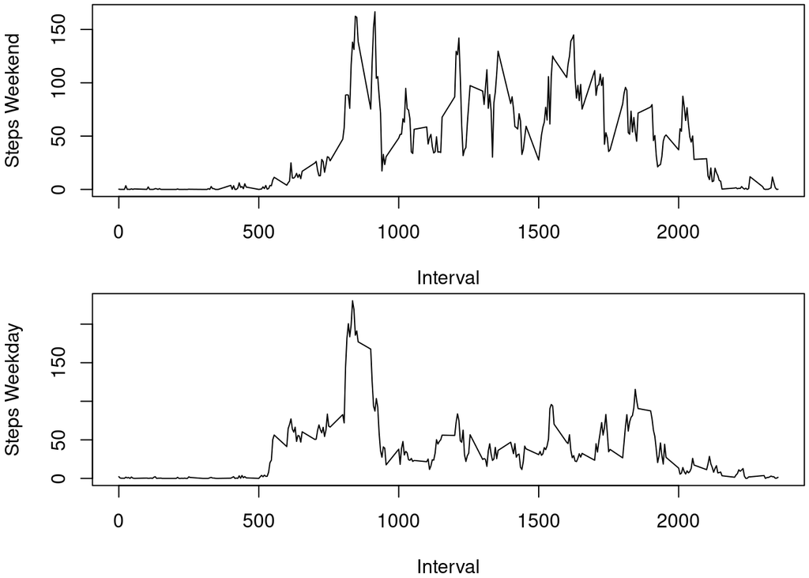